# Final Project

Scott Shang (8458655)

June 11, 2022

## Introduction

The purpose of this project is to generate a model that will predict the quality of wine based on physicochemical tests.

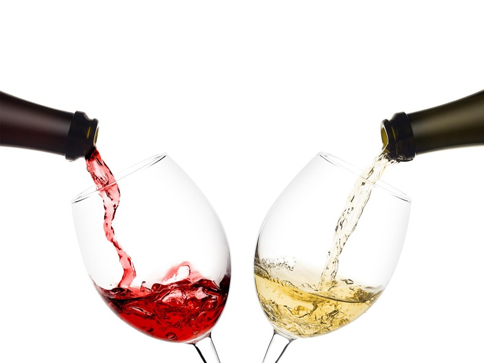

### Wine

Since 6000 BCE, wine has been produced for thousands of years in almost every single human country. This kind of alcoholic beverage is one of the most popular drink in the world. Wine also plays an essential role in worldwide culture and religion, from Eucharist to Kiddush. Wine is typically made from fermented grapes, the process that yeast consumes the sugar in the grapes and converts it to ethanol and carbon dioxide.

```r
embed_youtube("7gquYRxLMFI")
```

[video not shown]

### Why This Model Might Be Useful

For the people in the wine industry, this model can be helpful by illustrating what are the significant factors that determine the quality of wine so that they are able to improve the flavor and predict the quality of their product. For the consumers, this model can predict the quality of specific wines so people can find the better one.

### Data Set Overview

This data set is from [Kaggle](https://www.kaggle.com/datasets/uciml/red-wine-quality-cortez-et-al-2009). The following are the key variables:

- `fixed acidity`: The fixed acidity indicator of the wine.
- `volatile acidity`: The amount of acetic acid in the wine.
- `citric acid`: The amount of citric acid in the wine.
- `residual sugar`: The amount of sugar remaining after fermentation stops.
- `chlorides`: The amount of salt in the wine.
- `free sulfur dioxide`: The amount of free form of SO2 exists in the wine.
- `total sulfur dioxide`: The amount of free and bound forms of S02 in the wine.
- `density`: The density of the wine.
- `pH`: The pH value of the wine, describes how acidic or basic a wine is on a scale from 0 (very acidic) to 14 (very basic).
- `sulphates`: The amount of sulphates in the wine, which can contribute to sulfur dioxide gas (S02) levels, which acts as an antimicrobial.
- `alcohol`: The percent alcohol content of the wine.
- `quality`: The quality of wine (score between 3 and 8).

## Exploratory Data Analysis

Read the data.

```r
wine <- read_csv("data/wine_quality.csv") %>%
  clean_names()
head(wine)
```

| fixed_acidity | volatile_acidity | citric_acid | residual_sugar | chlorides | free_sulfur_dioxide | total_sulfur_dioxide | density | p_h | sulphates | alcohol | quality |
| --- | --- | --- | --- | --- | --- | --- | --- | --- | --- | --- | --- |
| 7.4 | 0.70 | 0.00 | 1.9 | 0.076 | 11 | 34 | 0.9978 | 3.51 | 0.56 | 9.4 | 5 |
| 7.8 | 0.88 | 0.00 | 2.6 | 0.098 | 25 | 67 | 0.9968 | 3.20 | 0.68 | 9.8 | 5 |
| 7.8 | 0.76 | 0.04 | 2.3 | 0.092 | 15 | 54 | 0.9970 | 3.26 | 0.65 | 9.8 | 5 |
| 11.2 | 0.28 | 0.56 | 1.9 | 0.075 | 17 | 60 | 0.9980 | 3.16 | 0.58 | 9.8 | 6 |
| 7.4 | 0.70 | 0.00 | 1.9 | 0.076 | 11 | 34 | 0.9978 | 3.51 | 0.56 | 9.4 | 5 |
| 7.4 | 0.66 | 0.00 | 1.8 | 0.075 | 13 | 40 | 0.9978 | 3.51 | 0.56 | 9.4 | 5 |

```r
wine <- wine %>%
  mutate(quality = factor(quality))
head(wine)
```

| fixed_acidity | volatile_acidity | citric_acid | residual_sugar | chlorides | free_sulfur_dioxide | total_sulfur_dioxide | density | p_h | sulphates | alcohol | quality |
| --- | --- | --- | --- | --- | --- | --- | --- | --- | --- | --- | --- |
| 7.4 | 0.70 | 0.00 | 1.9 | 0.076 | 11 | 34 | 0.9978 | 3.51 | 0.56 | 9.4 | 5 |
| 7.8 | 0.88 | 0.00 | 2.6 | 0.098 | 25 | 67 | 0.9968 | 3.20 | 0.68 | 9.8 | 5 |
| 7.8 | 0.76 | 0.04 | 2.3 | 0.092 | 15 | 54 | 0.9970 | 3.26 | 0.65 | 9.8 | 5 |
| 11.2 | 0.28 | 0.56 | 1.9 | 0.075 | 17 | 60 | 0.9980 | 3.16 | 0.58 | 9.8 | 6 |
| 7.4 | 0.70 | 0.00 | 1.9 | 0.076 | 11 | 34 | 0.9978 | 3.51 | 0.56 | 9.4 | 5 |
| 7.4 | 0.66 | 0.00 | 1.8 | 0.075 | 13 | 40 | 0.9978 | 3.51 | 0.56 | 9.4 | 5 |

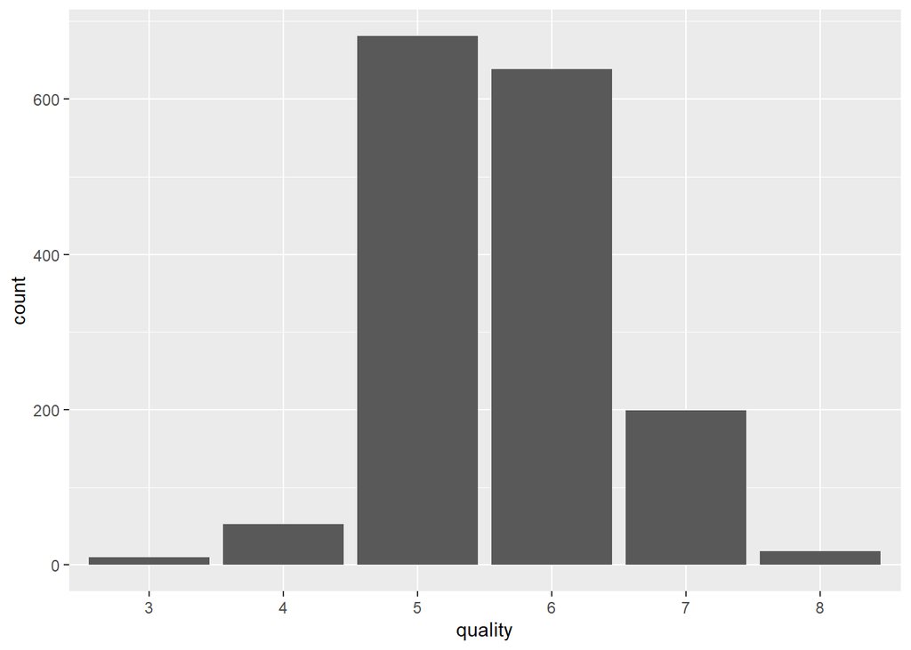

```r
wine %>%
  ggplot(aes(x = quality),color = 'white') +
  geom_bar()
```

Create a visualization of the correlation between all continuous predictors. We notice that free sulfur dioxide is positively correlated to total sulfur dioxide, which makes sense since total sulfur dioxide is composed by free and bounded sulfur dioxide. We also notice that fixed acidity is negatively correlated to the pH value. A reasonable explanation is that acidic solution tends to have smaller pH value.

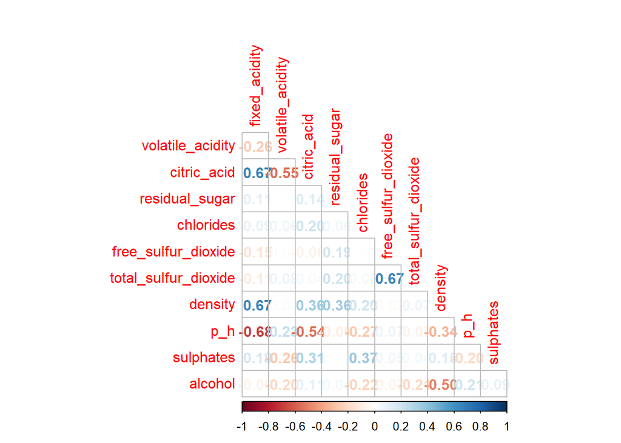

```r
wine %>%
  select(is.numeric) %>%
  cor(use = "complete.obs") %>%
  corrplot(method = "number", type = "lower", diag = FALSE)
```

The following graphs is a further step showing the correlation between variables. We choose the pairs of variables that are more related to each other, as shown in the last diagram, for example, ‘citric acid’:‘fixed acidity’, ‘density’:‘alcohol’, ‘pH’:‘fixed acidity’, and so on.

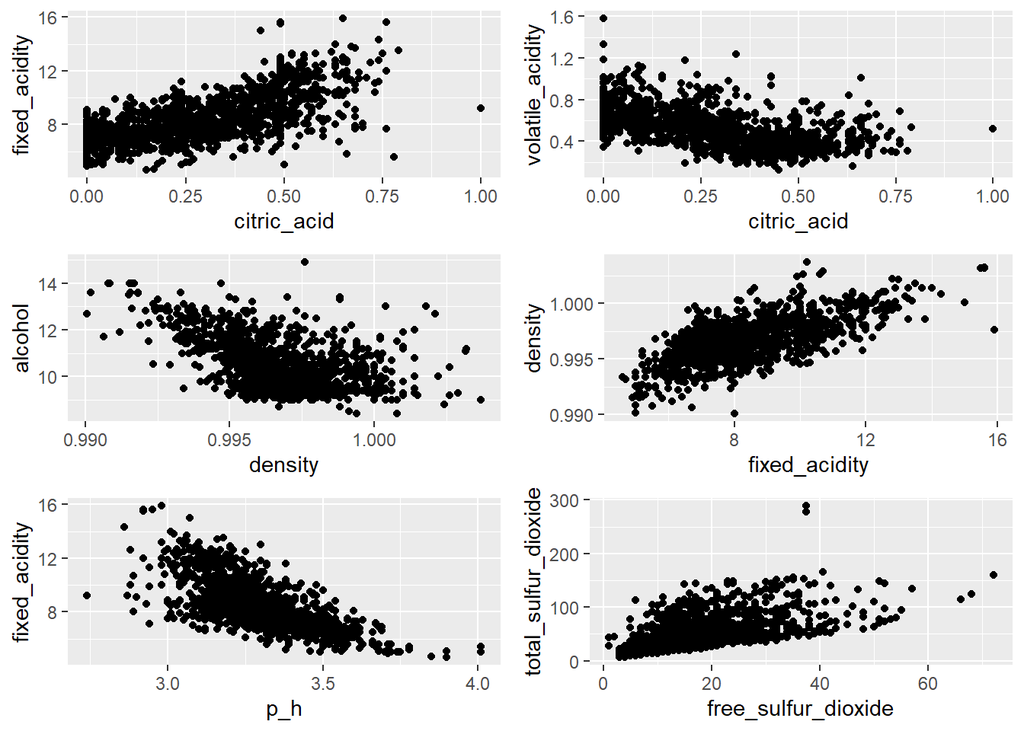

```r
graph1 <- wine %>% ggplot(aes(x = citric_acid, y = fixed_acidity)) + geom_point()
graph2 <- wine %>% ggplot(aes(x = citric_acid, y = volatile_acidity)) + geom_point()
graph3 <- wine %>% ggplot(aes(x = density, y = alcohol)) + geom_point()
graph4 <- wine %>% ggplot(aes(x = fixed_acidity, y = density)) + geom_point()
graph5 <- wine %>% ggplot(aes(x = p_h, y = fixed_acidity)) + geom_point()
graph6 <- wine %>% ggplot(aes(x = free_sulfur_dioxide, y = total_sulfur_dioxide)) + geom_point()
grid.arrange(graph1, graph2, graph3, graph4, graph5, graph6)
```

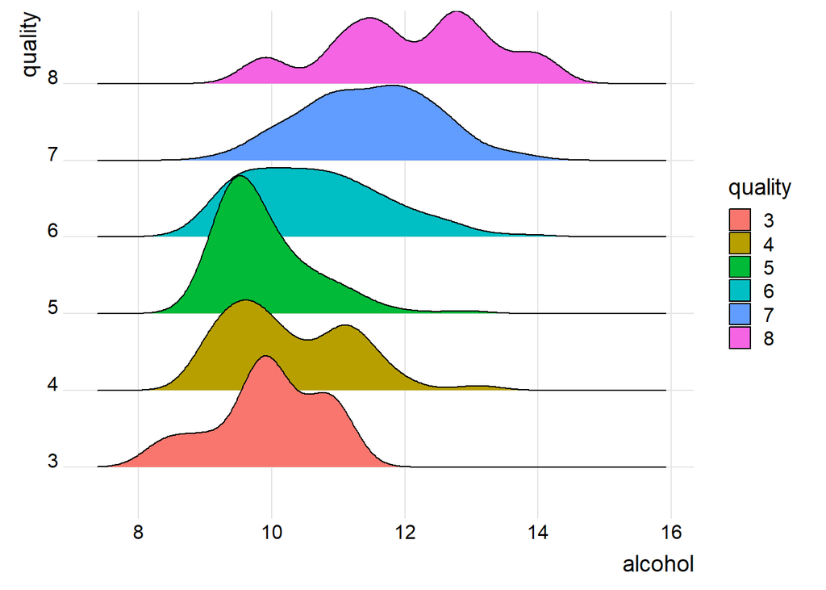

```r
ggplot(wine[!(wine$alcohol %in% c(0, 1)), ],aes(x=alcohol, y=quality, fill=quality)) +
  geom_density_ridges() +
  theme_ridges()
```

## Data Cleaning, Splitting, and Cross-validation

### Checking Missing Vallue

Check the summary of our data set, luckily we don’t have any missing value, so we don’t have to use ‘mutate’.

```r
wine %>%
  summary()
```

```
##  fixed_acidity   volatile_acidity  citric_acid    residual_sugar
##  Min.   : 4.60   Min.   :0.120    Min.   :0.000   Min.   : 0.90
##  1st Qu.: 7.10   1st Qu.:0.390    1st Qu.:0.090   1st Qu.: 1.90
##  Median : 7.90   Median :0.520    Median :0.260   Median : 2.20
##  Mean   : 8.32   Mean   :0.528    Mean   :0.271   Mean   : 2.54
##  3rd Qu.: 9.20   3rd Qu.:0.640    3rd Qu.:0.420   3rd Qu.: 2.60
##  Max.   :15.90   Max.   :1.580    Max.   :1.000   Max.   :15.50
##    chlorides      free_sulfur_dioxide total_sulfur_dioxide    density
##  Min.   :0.0120   Min.   : 1.0        Min.   :  6.0        Min.   :0.990
##  1st Qu.:0.0700   1st Qu.: 7.0        1st Qu.: 22.0        1st Qu.:0.996
##  Median :0.0790   Median :14.0        Median : 38.0        Median :0.997
##  Mean   :0.0875   Mean   :15.9        Mean   : 46.5        Mean   :0.997
##  3rd Qu.:0.0900   3rd Qu.:21.0        3rd Qu.: 62.0        3rd Qu.:0.998
##  Max.   :0.6110   Max.   :72.0        Max.   :289.0        Max.   :1.004
##       p_h         sulphates        alcohol     quality
##  Min.   :2.74   Min.   :0.330   Min.   : 8.4   3: 10
##  1st Qu.:3.21   1st Qu.:0.550   1st Qu.: 9.5   4: 53
##  Median :3.31   Median :0.620   Median :10.2   5:681
##  Mean   :3.31   Mean   :0.658   Mean   :10.4   6:638
##  3rd Qu.:3.40   3rd Qu.:0.730   3rd Qu.:11.1   7:199
##  Max.   :4.01   Max.   :2.000   Max.   :14.9   8: 18
```

### Data Spliting

The data is split by 80% training and 20% testing with stratify our response variable ‘quality’.

```r
set.seed(1234) # you can use any number you like
split <- wine %>% initial_split(strata = quality,
                                           prop = 0.8)
```

Verify that the training and testing data sets have the appropriate number of observations.

```r
train <- training(split)
test <- testing(split)
dim(train)
```

```
## [1] 1278   12
```

```r
dim(test)
```

```
## [1] 321  12
```

### Creating Folds and Recipe

Using Cross Validation, we create a 3-fold validation, stratified by the quality of wine. We think 3-fold validation is sufficient for the model since our data set contains 1599 observations, which is a lot.

```r
set.seed(1234)
folds <- vfold_cv(train, strata = 'quality',
                          v = 3)
```

```r
#recipe
rcp <- recipe(quality ~ . , data = wine) %>%
  step_normalize(all_predictors())
```

## Model Building

Since the Quality of wine only takes 3, 4, 5, 6, 7, and 8, we solve this classification task by fitting the training data to the following models: support vector machine, decision tree, random forest, and boosted trees model.

### SVM

```r
svm_spec=svm_poly(cost = tune(), degree = tune()) %>%
  set_engine("kernlab") %>%
  set_mode("classification")
svm_wf=workflow() %>%
  add_model(svm_spec) %>%
  add_recipe(rcp)
svm_grid=grid_regular(cost(), degree(), levels=3)
svm_tune_res=svm_wf %>%
  tune_grid(resamples = folds, grid = svm_grid, metrics = metric_set(roc_auc, accuracy))

svm_best=select_best(svm_tune_res)
collect_metrics(svm_tune_res) %>%
  arrange(-mean)
```

| cost | degree | .metric | .estimator | mean | n | std_err | .config |
| --- | --- | --- | --- | --- | --- | --- | --- |
| 9.766e-04 | 2 | roc_auc | hand_till | 0.6838 | 3 | 0.020651 | Preprocessor1_Model4 |
| 9.766e-04 | 3 | roc_auc | hand_till | 0.6806 | 3 | 0.004050 | Preprocessor1_Model7 |
| 9.766e-04 | 1 | roc_auc | hand_till | 0.6700 | 3 | 0.008894 | Preprocessor1_Model1 |
| 1.768e-01 | 3 | roc_auc | hand_till | 0.6651 | 3 | 0.015119 | Preprocessor1_Model8 |
| 3.200e+01 | 1 | roc_auc | hand_till | 0.6647 | 3 | 0.014573 | Preprocessor1_Model3 |
| 1.768e-01 | 1 | roc_auc | hand_till | 0.6584 | 3 | 0.008964 | Preprocessor1_Model2 |
| 3.200e+01 | 3 | roc_auc | hand_till | 0.6557 | 3 | 0.022449 | Preprocessor1_Model9 |
| 1.768e-01 | 2 | roc_auc | hand_till | 0.6391 | 3 | 0.038713 | Preprocessor1_Model5 |
| 3.200e+01 | 2 | roc_auc | hand_till | 0.6327 | 3 | 0.007345 | Preprocessor1_Model6 |
| 9.766e-04 | 3 | accuracy | multiclass | 0.6040 | 3 | 0.011732 | Preprocessor1_Model7 |

[output cut: 8 more lines]

### Decision Tree Model

```r
#Decision Tree Model
tree_spec=decision_tree() %>%
  set_engine("rpart")

class_tree_spec=tree_spec %>%
  set_mode("classification")

class_tree_wf=workflow() %>%
  add_model(class_tree_spec %>%
  set_args(cost_complexity = tune())) %>%
  add_recipe(rcp)

class_tree_grid=grid_regular(cost_complexity(range = c(-10, -1)), levels = 10)

class_tree_tune_res=tune_grid(
  class_tree_wf,
  resamples=folds,
  grid=class_tree_grid,
  metrics=metric_set(roc_auc)
)

collect_metrics(class_tree_tune_res) %>%
  arrange(-mean)
```

| cost_complexity | .metric | .estimator | mean | n | std_err | .config |
| --- | --- | --- | --- | --- | --- | --- |
| 1e-02 | roc_auc | hand_till | 0.6896 | 3 | 0.01516 | Preprocessor1_Model09 |
| 1e-10 | roc_auc | hand_till | 0.6412 | 3 | 0.02086 | Preprocessor1_Model01 |
| 1e-09 | roc_auc | hand_till | 0.6412 | 3 | 0.02086 | Preprocessor1_Model02 |
| 1e-08 | roc_auc | hand_till | 0.6412 | 3 | 0.02086 | Preprocessor1_Model03 |
| 1e-07 | roc_auc | hand_till | 0.6412 | 3 | 0.02086 | Preprocessor1_Model04 |
| 1e-06 | roc_auc | hand_till | 0.6412 | 3 | 0.02086 | Preprocessor1_Model05 |
| 1e-05 | roc_auc | hand_till | 0.6412 | 3 | 0.02086 | Preprocessor1_Model06 |
| 1e-04 | roc_auc | hand_till | 0.6412 | 3 | 0.02086 | Preprocessor1_Model07 |
| 1e-03 | roc_auc | hand_till | 0.6412 | 3 | 0.02086 | Preprocessor1_Model08 |
| 1e-01 | roc_auc | hand_till | 0.6056 | 3 | 0.02643 | Preprocessor1_Model10 |

Using ‘rpart.plot’, we visualize our best-performing pruned decision tree with our training data set.

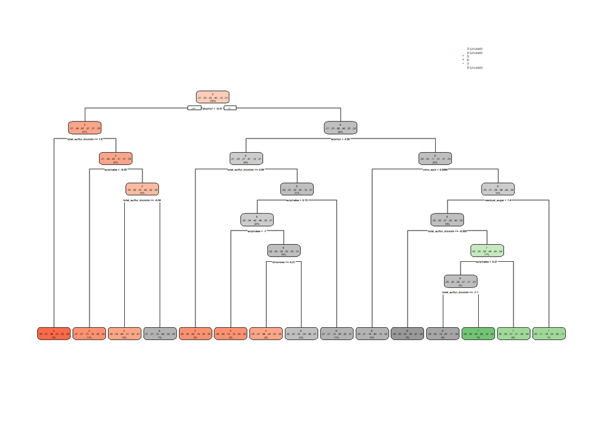

```r
class_tree_best=select_best(class_tree_tune_res)

class_tree_final=finalize_workflow(class_tree_wf,class_tree_best)

class_tree_final_fit=fit(class_tree_final,data=train)

class_tree_final_fit %>%
  extract_fit_engine() %>%
  rpart.plot()
```

### Boosted Trees Model

```r
#Boosted Trees
boosted_spec=boost_tree(trees=tune()) %>%
  set_engine("xgboost") %>%
  set_mode("classification")

boosted_wf=workflow() %>%
  add_recipe(rcp) %>%
  add_model(boosted_spec)

grid_boosted=grid_regular(trees(range=c(10,2000)),levels = 10)

tune_res_boosted=tune_grid(
  boosted_wf,
  resamples=folds,
  grid=grid_boosted,
  metrics=metric_set(roc_auc))

boost_best=select_best(tune_res_boosted)

collect_metrics(tune_res_boosted) %>%
  arrange(-mean)
```

| trees | .metric | .estimator | mean | n | std_err | .config |
| --- | --- | --- | --- | --- | --- | --- |
| 231 | roc_auc | hand_till | 0.7891 | 3 | 0.02133 | Preprocessor1_Model02 |
| 452 | roc_auc | hand_till | 0.7859 | 3 | 0.01880 | Preprocessor1_Model03 |
| 673 | roc_auc | hand_till | 0.7854 | 3 | 0.01594 | Preprocessor1_Model04 |
| 894 | roc_auc | hand_till | 0.7847 | 3 | 0.01493 | Preprocessor1_Model05 |
| 1115 | roc_auc | hand_till | 0.7831 | 3 | 0.01357 | Preprocessor1_Model06 |
| 1336 | roc_auc | hand_till | 0.7811 | 3 | 0.01307 | Preprocessor1_Model07 |
| 2000 | roc_auc | hand_till | 0.7802 | 3 | 0.01171 | Preprocessor1_Model10 |
| 1557 | roc_auc | hand_till | 0.7802 | 3 | 0.01243 | Preprocessor1_Model08 |
| 1778 | roc_auc | hand_till | 0.7797 | 3 | 0.01267 | Preprocessor1_Model09 |
| 10 | roc_auc | hand_till | 0.7747 | 3 | 0.02233 | Preprocessor1_Model01 |